# Foundations for statistical inference - Confidence intervals

I have added extra comments and code lines in this document. Ideally, go over the regular lab and then read this one. Hope this helps!

**Extra note on Setting a seed:** To set the seed you literally choose any number, whatever you want. Setting a seed doesn’t mean that every time you sample you will obtain the same number in a consecutive way. If I create a vector called `x` with values `1-10` and then I draw a random number it will give me any number from `1-10`. If I draw another random number it will give me another number or perhaps the same. For example, it can give me a `5` the first time, and a `2` the second time. If I re-run the two lines it might give me a `3` the first time and a `9` the second time. OR whatever… *It will change every time*. **However**, if I set a seed ( for example `2222` ) it will give me a `4` the first time and then if I draw another random number it will give me a `2`, then a `9`. So I am getting different random numbers but now I know that setting the seed `2222` will give me those numbers in that order. AND more importantly, when you run the example I am describing here you will get the **same** results.

```r
x <- seq(1:10)
set.seed(2222)
sample(x, 1)
```

```
## [1] 4
```

```r
sample(x, 1)
```

```
## [1] 2
```

```r
sample(x, 1)
```

```
## [1] 9
```

## The data

The main point here in relation to the data is that this data-set is actually the **population**. We rarely have that luxury.

```r
load(url("https://raw.githubusercontent.com/GarciaRios/govt_3990/gh-pages/Labs/lab4/data/ames.RData"))
```

```r
n <- 100
samp <- sample_n(ames, n)
```

- While the data-set has many housing variables, we are going to focus on the size of the house, represented by the variable `Lot.Area`.

```r
samp %>% select(1:7) %>%
  slice(1:15)
```

```
##    Order       PID MS.SubClass MS.Zoning Lot.Frontage Lot.Area Street
## 1   2029 903430040          45        RM           40     5680   Pave
## 2    313 914478045          80        RL           NA    12328   Pave
## 3    520 528458060          20        FV           72     8640   Pave
## 4   2240 910204090          30        RM           60     8967   Pave
## 5     16 527216070          60        RL           47    53504   Pave
## 6   1825 532377050          20        RL           84     7476   Pave
## 7   2058 905104240         190        RL           70     8425   Pave
## 8   2233 910200110          50        RM           50     7000   Pave
## 9    747 903236040          30        RM           50     8635   Pave
## 10  1784 528435010          20        RL           85     9965   Pave
## 11   401 527425060          20        RL           70    10500   Pave
## 12  1935 535305180          20        RL           66     8923   Pave
## 13   100 533213030          20        FV           NA     4403   Pave
## 14  2685 903236200          45        RM           58     6380   Pave
## 15    61 528344070          60        RL           60    17433   Pave
```

1. Describe the distribution of homes in your sample. What would you say is the “typical” size within your sample? Also state precisely what you interpreted “typical” to mean. later
2. Would you expect another classmate’s distribution to be identical to yours? Would you expect it to be similar? Why or why not?

## Confidence intervals

- Make sure you go over this section and read carefully, it’s important

Return for a moment to the question that first motivated this lab: based on this sample, what can we infer about the population? Based only on this single sample, the best estimate of the average living area of houses sold in Ames would be the sample mean, usually denoted as $\bar{x}$ (here we’re calling it `x_bar`). That serves as a good **point estimate** but it would be useful to also communicate how uncertain we are of that estimate. This uncertainty can be quantified using a **confidence interval**.

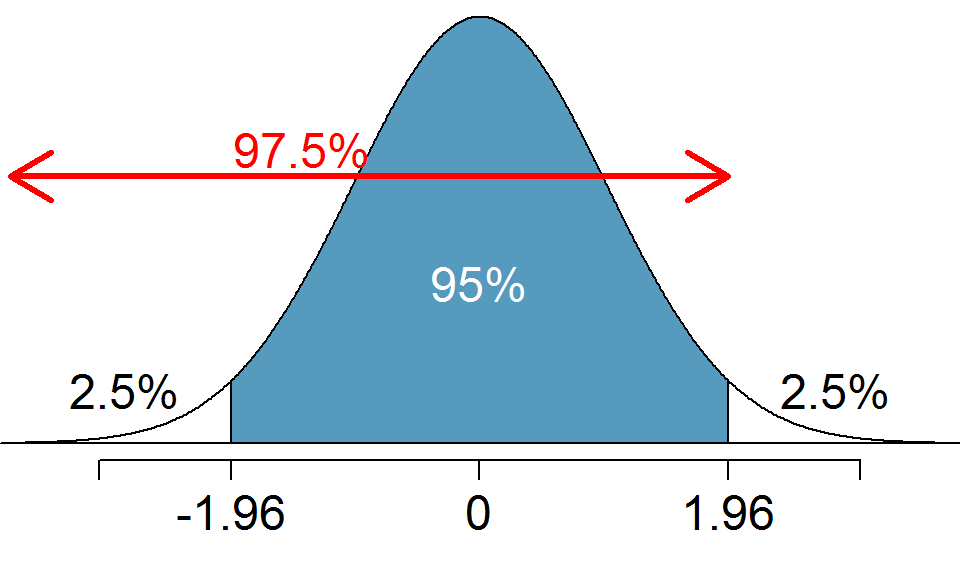

We can find the critical value for a 95% confidence interval using

```r
z_star_95 <- qnorm(0.975)
z_star_95
```

```
## [1] 1.959964
```

which is roughly equal to the value critical value 1.96 that you’re likely familiar with by now.

Let’s finally calculate the confidence interval.

```r
samp %>%
  summarise(lower = mean(Lot.Area) - z_star_95 * (sd(Lot.Area) / sqrt(n)),
            upper = mean(Lot.Area) + z_star_95 * (sd(Lot.Area) / sqrt(n)))
```

```
##    lower    upper
## 1 8597.4 11492.58
```

In addition to calculating the lower and upper bounds, for teaching purposes, it might be useful to also estimate the mean right there, Like this

```r
samp %>%
  summarise(lower = mean(Lot.Area) - z_star_95 * (sd(Lot.Area) / sqrt(n)),
            mean = mean(Lot.Area),
            upper = mean(Lot.Area) + z_star_95 * (sd(Lot.Area) / sqrt(n)))
```

```
##    lower     mean    upper
## 1 8597.4 10044.99 11492.58
```

- You can see that the estimated mean obviously falls right in the middle.. .

To recap: even though we don’t know what the full population looks like, we’re 95% confident that the true average size of houses in Ames lies between the values *lower* and *upper*. There are a few conditions that must be met for this interval to be valid.

1. For the confidence interval to be valid, the sample mean must be normally distributed and have standard error $s / \sqrt{n}$. What conditions must be met for this to be true?

## Confidence levels

1. What does “95% confidence” mean?

Again, in this case we have the rare luxury of knowing the true population mean since we have data on the entire population. Let’s calculate this value so that we can determine if our confidence intervals actually capture it. We’ll store it in a data frame called `params` (short for population parameters), and name it `mu`.

```r
params <- ames %>%
  summarise(mu = mean(Lot.Area))
```

- Again, we will be using different seeds so if you are working in groups your `mu` might not be captured by your sample, and perhaps your friend’s sample does capture it, that’s fine just keep going you’ll see why…
1. Does your confidence interval capture the true average size of houses in Ames? does your neighbor’s interval capture this value?
2. Each student should have gotten a slightly different confidence interval. What proportion of those intervals would you expect to capture the true population mean? Why?

Using R, we’re going to collect many samples to learn more about how sample means and confidence intervals vary from one sample to another.

Here is the rough outline:

- Obtain a random sample.
- Calculate the sample’s mean and standard deviation, and use these to calculate and store the lower and upper bounds of the confidence intervals.
- Repeat these steps 50 times.

```r
ci <- do(50) * ames %>%
                  sample_n(n) %>%
  summarise(lower = mean(Lot.Area) - z_star_95 * (sd(Lot.Area) / sqrt(n)),
            upper = mean(Lot.Area) + z_star_95 * (sd(Lot.Area) / sqrt(n)))
```

Let’s view the first five intervals:

```r
ci %>%
  slice(1:5)
```

```
##      lower    upper .row .index
## 1 8289.005 12735.18    1      1
## 2 8851.005 11510.16    1      2
## 3 9859.579 12345.28    1      3
## 4 8618.215 10549.50    1      4
## 5 8609.572 10381.77    1      5
```

Next we’ll create a plot similar to Figure 4.8 on page 175 of [OpenIntro Statistics, 3rd Edition](https://www.openintro.org/os). First step will be to create a new variable in the `ci` data frame that indicates whether the interval does or does not capture the true population mean. Note that capturing this value would mean the lower bound of the confidence interval is below the value and upper bound of the confidence interval is above the value. Remember that we create new variables using the `mutate` function.

```r
ci <- ci %>%
  mutate(capture_mu = ifelse(lower < params$mu & upper > params$mu, "yes", "no"))
```

- I don’t know if you are struggling with `iflelse`… it’s not very intuitive so hopefully this extra explanation helps.

The `ifelse` takes three arguments: first is a logical statement, second is the value we want if the logical statement yields a true result, and the third is the value we want if the logical statement yields a false result.

- (In this case we use `mutate` to create a variable that would have two values: “yes” and “no”. The values would be assigned using `iflese`: if the lower bound is less than `mu` AND the upper bound greater than `mu`, the assigned value would be “yes”, OTHERWISE it will be “no”)

We now have all the information we need to create the plot, but we need to re-organize our data a bit for easy plotting. Specifically, we need to organize the data in a new data frame where each row represents one bound, as opposed to one interval. So this

```
     lower    upper capture_mu
1 1355.688 1559.545        yes
2 1413.661 1681.673        yes
3 1372.159 1631.807        yes
...
```

should instead look like

```
  ci_id ci_bounds capture_mu
1     1  1355.688        yes
2     2  1413.661        yes
3     3  1372.159        yes
4     1  1559.545        yes
5     2  1681.673        yes
6     3  1631.807        yes
...
```

We can accomplish this using the following:

```r
ci_data <- data.frame(ci_id = c(1:50, 1:50),
                      ci_bounds = c(ci$lower, ci$upper),
                      capture_mu = c(ci$capture_mu, ci$capture_mu))
```

And finally we can create the plot using the following:

```r
ggplot(ci_data, aes(x = ci_bounds, y = ci_id,
      group = ci_id, color = capture_mu)) +
  geom_point(size = 2) +  # add points at the ends, size = 2
  geom_line() +           # connect with lines
  geom_vline(xintercept = params$mu, color = "darkgray") # draw vertical line
```

[output not shown]

- At this point if you created the plot you should be able to understand the purpose of the lab, it should be more intuitive at this point.
1. What proportion of your confidence intervals include the true population mean? Is this proportion exactly equal to the confidence level? If not, explain why. Make sure to include your plot in your answer.

## On your own

- Pick a confidence level of your choosing, provided it is not 95%. What is the appropriate critical value?
- Calculate 50 confidence intervals at the confidence level you chose in the previous question, and plot all intervals on one plot, and calculate the proportion of intervals that include the true population mean. How does this percentage compare to the confidence level selected for the intervals? Make sure to include your plot in your answer.